# Coursework Report

*N* removed NAs: 2

*N* removed typo: 1

*N* removed <18: 22

*N* total clean: 125

| Group | *N* | *M*<sub>age</sub> | *M*<sub>rating</sub> |
| --- | --- | --- | --- |
| Control | 66 | 21.56 | 6.47 |
| Experim | 59 | 21.39 | 5.75 |

**Main analysis results**

*t*(123) = 5.36, *p* < .001

[interactive chart not shown]

[figure not shown]

[interactive chart not shown]

# Coursework Report

Analysing Data, Spring 2020

Table 1 Data Summary

| Groups | Mean Attractiveness Score | SD Attractiveness Score |
| --- | --- | --- |
| Red Colour Condition | 6.56 | 0.76 |
| White Colour Condition | 5.75 | 0.72 |

Table 2 Descriptive Statistics

|  | Test Group | Mean | SD | Min | Max |
| --- | --- | --- | --- | --- | --- |
| Question 1 | White Colour Condition | 5.66 | 1.34 | 3 | 9 |
| Question 2 | White Colour Condition | 5.68 | 1.29 | 2 | 8 |
| Question 3 | White Colour Condition | 5.92 | 1.25 | 3 | 9 |
| Question 1* | Red Colour Condition | 6.45 | 1.42 | 3 | 9 |
| Question 2* | Red Colour Condition | 6.52 | 1.19 | 4 | 9 |
| Question 3* | Red Colour Condition | 6.69 | 1.38 | 4 | 9 |
| Age | NA | 20.94 | 2.82 | 16 | 30 |

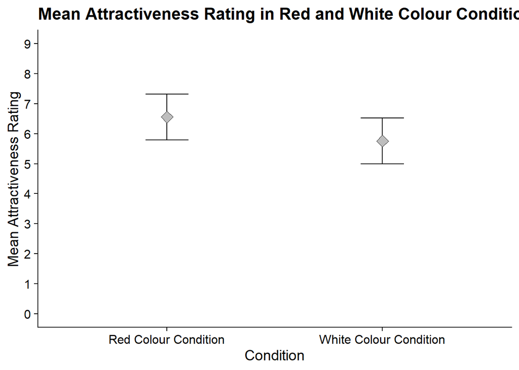

```
##
##  Two Sample t-test
##
## data:  QUESTION_1/3 + QUESTION_2/3 + QUESTION_3/3 by GROUP
## t = 6.3785, df = 138, p-value = 0.000000002512
## alternative hypothesis: true difference in means is not equal to 0
## 95 percent confidence interval:
##  0.5531846 1.0502342
## sample estimates:
##   mean in group Red Colour Condition mean in group White Colour Condition
##                             6.555556                             5.753846
```

# Methods

## Participants

150 females initially participated in the experiment but the data was adjusted down to 140 to exclude data points that weren’t complete or had people of ages that were unnapplicable to this study (e.g. people under 16). The final group of participants were aged 16-30, had a mean age of 20.94 and a significance difference of 2.82 as shown on Table 2.

## Design

This study looked at the effect of the colour red on female’s perceptions of male’s attractiveness, in an attempt to replicate the study done by Elliot et al (2010). Our independent variable, which had 2 levels, was the photo of a male on either a white or red background, as to test the effect of colour, while our dependent variable, and what we measured, was a series of likert-scale questions given to the female participants asking how attractive they found the male in the photos to be. Female participants experienced only 1 level of the independent variable thus making this study an independent measures design and will therefore be tested using an independent-measures t-test. A higher mean score in the red level than in the white level would mean that a male presented in conjunction with the colour red is seen as more attractive.

# Results

Means and standard deviations of the 2 conditions can be found in Table 1 Data Summary

# Discussion

The results show that the photos of males on red backgrounds were, on average, rated as more attractive than those on the white background. This replication supports the results shown in the original study done by Elliot et al whose first experiment found the red colour condition to have a mean of 6.79 (SD 1.00) and white colour condition to have a mean of 5.67 (SD 1.34). This suggests that there is a link between the colour and attractiveness. However, other studies have found no effect of colour on attractiveness (Peperkoorn et al., 2016) and additionally, this study only represents male to female attractiveness while other studies have found conflicting results such as where men have been found to find red more attractive on women in comparison to white, green and yellow but not in comparison to black (Roberts, Owen, and Havlicek, 2010). While this study has strong inter-rater and test-retest reliability and thus can be replicated, it would be pointless for further research in this field to occur. Many studies show an effect while many do not but yet the research question itself is not something that is wholly important for society and a simple change of colour is not the primary reason for attractiveness. While this study,and its original version, show that the colour red makes a male more attractive, it is not something worth disputing further.

# References

Elliot, A. J., Niesta Kayser, D., Greitemeyer, T., Lichtenfeld, S., Gramzow, R. H., Maier, M. A., & Liu, H. (2010). Red, rank, and romance in women viewing men. Journal of Experimental Psychology: General, 139(3), 399–417. https://doi.org/10.1037/a0019689

Peperkoorn, L. S., Roberts, S. C., & Pollet, T. V. (2016). Revisiting the Red Effect on Attractiveness and Sexual Receptivity: No Effect of the Color Red on Human Mate Preferences. Evolutionary Psychology, 14(4), 1474704916673841. https://doi.org/10.1177/1474704916673841

Roberts, S. C., Owen, R. C., & Havlicek, J. (2010). Distinguishing between Perceiver and Wearer Effects in Clothing Color-Associated Attributions: Evolutionary Psychology. https://doi.org/10.1177/147470491000800304